# Studying on Iris Dataset

Mehmet Kadri Gofralılar

11/25/2021

## Preparations

First, we import libraries that we need to use. Then, we should assign our dataset **Iris** to a variable in order to use it.

```r
library(ggplot2)
library(dplyr)
library(factoextra)
library(cluster)
library(stats)

data <- iris
str(data)
```

```
## 'data.frame':    150 obs. of  5 variables:
##  $ Sepal.Length: num  5.1 4.9 4.7 4.6 5 5.4 4.6 5 4.4 4.9 ...
##  $ Sepal.Width : num  3.5 3 3.2 3.1 3.6 3.9 3.4 3.4 2.9 3.1 ...
##  $ Petal.Length: num  1.4 1.4 1.3 1.5 1.4 1.7 1.4 1.5 1.4 1.5 ...
##  $ Petal.Width : num  0.2 0.2 0.2 0.2 0.2 0.4 0.3 0.2 0.2 0.1 ...
##  $ Species     : Factor w/ 3 levels "setosa","versicolor",..: 1 1 1 1 1 1 1 1 1 1 ...
```

We can see that we have 4 numeric columns and 1 factorized column.

## Plot

Now, we will plot `“sepal width”` vs `“sepal length”`, coloring the points according to their `species`.

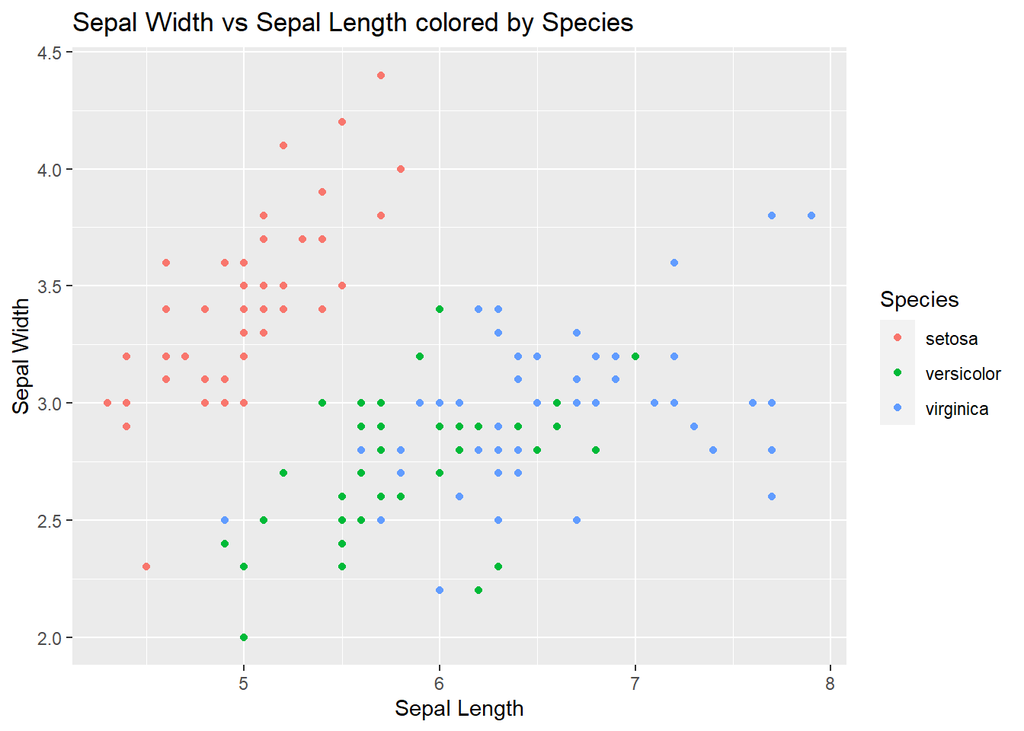

```r
width_length <-ggplot(data) +
  geom_point(mapping=aes(x = Sepal.Length, y= Sepal.Width, colour = Species))+
  labs(
    x = "Sepal Length",
    y = "Sepal Width",
    title = "Sepal Width vs Sepal Length colored by Species")

width_length
```

## Apply PCA

Now, we will apply **principle component analysis(PCA)** to see potential number of `clusters`.

```r
pca <- prcomp(data[1:4] ,center = TRUE, scale = TRUE)
summary(pca)
```

```
## Importance of components:
##                           PC1    PC2     PC3     PC4
## Standard deviation     1.7084 0.9560 0.38309 0.14393
## Proportion of Variance 0.7296 0.2285 0.03669 0.00518
## Cumulative Proportion  0.7296 0.9581 0.99482 1.00000
```

We can see that it’s possible to represent the whole dataset by using 4 components at total. But it’s easy to say that first 2 or 3 components can represent a big percentage of our dataset. Last component is the least important one and covers too less of our dataset. Therefore, probably 3 clusters will be okay for us to use.

## Plot PCA

Next, we will use `fviz_pca_ind` function to plot **2-D PCA plot**.

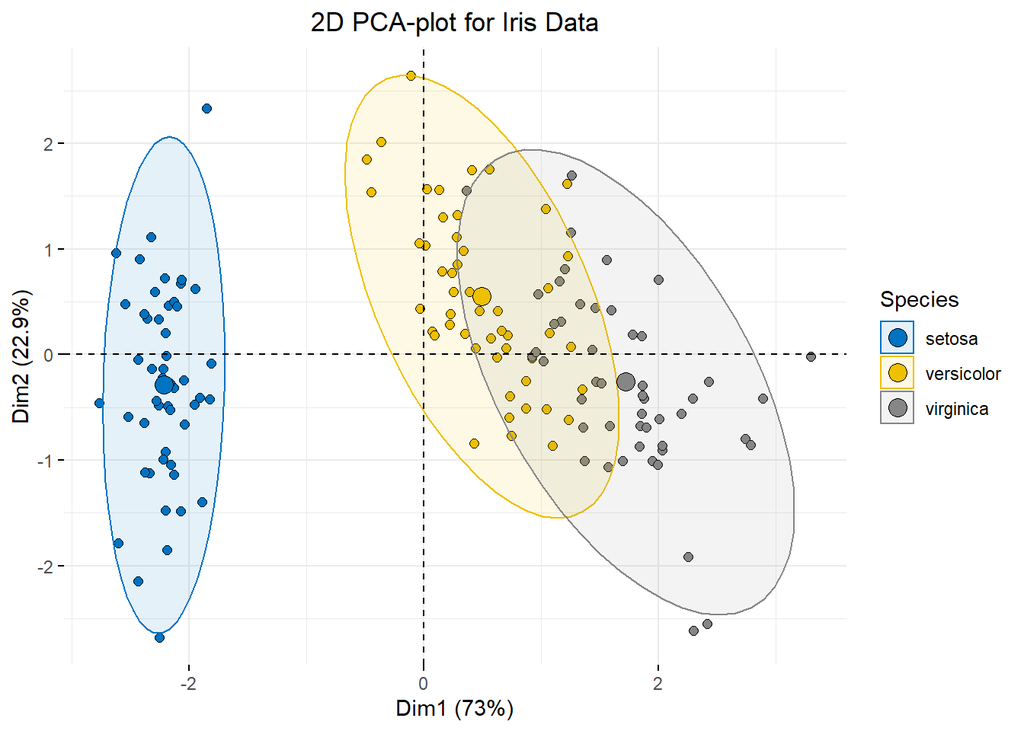

```r
pca_plot <- fviz_pca_ind(pca, geom.ind = "point", pointshape = 21,
             pointsize = 2,
             fill.ind = data$Species,
             col.ind = "black",
             palette = "jco",
             addEllipses = TRUE,
             label = "var",
             col.var = "black",
             repel = TRUE,
             legend.title = "Species") +
  ggtitle("2D PCA-plot for Iris Data") +
  theme(plot.title = element_text(hjust = 0.5))

pca_plot
```

We can see that there are a couple of outlier points. **Setosa**s are quite seperated from others, but **Versicolor**s and **Virginica**s have a big intersection area.

## Apply kmeans Clustring

Now, we will apply **kmeans clustering**, which groups our data in a number of groups given by us.

```r
set.seed (102)
clusters <- kmeans(data[1:4], 3)
```

## Compare kmeans Clustring and True Values

Lets compare our predictions aquired by applying **kmeans clustering** with our true values.

```r
kmeans_prediction_of_species <- clusters$cluster

kmeans_prediction_of_species <-
replace(kmeans_prediction_of_species, kmeans_prediction_of_species==1,"virginica")

kmeans_prediction_of_species <-
replace(kmeans_prediction_of_species, kmeans_prediction_of_species==2,"setosa")

kmeans_prediction_of_species <-
replace(kmeans_prediction_of_species, kmeans_prediction_of_species==3,"versicolor")

true_species <- data$Species

comparison1 <- data.frame(as.factor(kmeans_prediction_of_species),true_species)

head(comparison1,7)
```

```
##   as.factor.kmeans_prediction_of_species. true_species
## 1                                  setosa       setosa
## 2                                  setosa       setosa
## 3                                  setosa       setosa
## 4                                  setosa       setosa
## 5                                  setosa       setosa
## 6                                  setosa       setosa
## 7                                  setosa       setosa
```

```r
tail(comparison1,7)
```

```
##     as.factor.kmeans_prediction_of_species. true_species
## 144                               virginica    virginica
## 145                               virginica    virginica
## 146                               virginica    virginica
## 147                              versicolor    virginica
## 148                               virginica    virginica
## 149                               virginica    virginica
## 150                              versicolor    virginica
```

```r
mean(kmeans_prediction_of_species == true_species)
```

```
## [1] 0.8933333
```

It’s possible to say that getting **89%** of the predictions correct is not a bad rate in this much of a small amount of data.

## Apply Agglomerative Hierarchical Clustering

Now, we will apply **Agglomerative Hierarchical Clustering**, which separates our data until reaching it’s end in a few steps in a tree-like structure.

```r
distance <- dist(data, method = "euclidean")

hierarchical_clustering <- hclust(distance, method = "average" )
```

## Plot Dendogram

Lets plot the `dendrogram`.

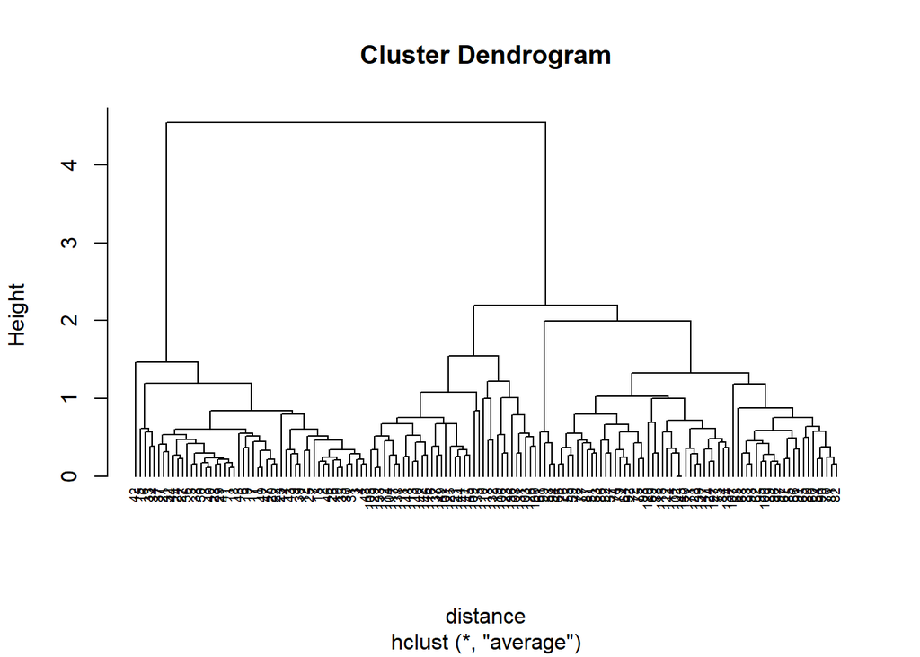

```r
plot(hierarchical_clustering, cex = 0.6, hang = -1)
```

## Compare Agglomerative Hierarchical and True Values

```r
hierarchically_clustered_data_predictions <- cutree(hierarchical_clustering, k = 3)
hierarchically_clustered_data_predictions
```

```
##   [1] 1 1 1 1 1 1 1 1 1 1 1 1 1 1 1 1 1 1 1 1 1 1 1 1 1 1 1 1 1 1 1 1 1 1 1 1 1
##  [38] 1 1 1 1 1 1 1 1 1 1 1 1 1 2 2 2 2 2 2 2 2 2 2 2 2 2 2 2 2 2 2 2 2 2 2 2 2
##  [75] 2 2 2 2 2 2 2 2 2 2 2 2 2 2 2 2 2 2 2 2 2 2 2 2 2 2 3 2 3 3 3 3 2 3 3 3 3
## [112] 3 3 2 2 3 3 3 3 2 3 2 3 2 3 3 2 2 3 3 3 3 3 2 3 3 3 3 2 3 3 3 2 3 3 3 2 3
## [149] 3 2
```

```r
hierarchically_clustered_data_predictions <-
replace(hierarchically_clustered_data_predictions, hierarchically_clustered_data_predictions==1,"setosa")

hierarchically_clustered_data_predictions <-
replace(hierarchically_clustered_data_predictions, hierarchically_clustered_data_predictions==2,"versicolor")

hierarchically_clustered_data_predictions <-
replace(hierarchically_clustered_data_predictions, hierarchically_clustered_data_predictions==3,"virginica")

comparison2 <- data.frame(as.factor(hierarchically_clustered_data_predictions),true_species)

head(comparison2,7)
```

```
##   as.factor.hierarchically_clustered_data_predictions. true_species
## 1                                               setosa       setosa
## 2                                               setosa       setosa
## 3                                               setosa       setosa
## 4                                               setosa       setosa
## 5                                               setosa       setosa
## 6                                               setosa       setosa
## 7                                               setosa       setosa
```

```r
tail(comparison2,7)
```

```
##     as.factor.hierarchically_clustered_data_predictions. true_species
## 144                                            virginica    virginica
## 145                                            virginica    virginica
## 146                                            virginica    virginica
## 147                                           versicolor    virginica
## 148                                            virginica    virginica
## 149                                            virginica    virginica
## 150                                           versicolor    virginica
```

```r
mean(hierarchically_clustered_data_predictions == true_species)
```

```
## [1] 0.9066667
```

Since almost **91%** of the predictions are correct, we can say that Hierarchical Clustering might be a better way to make predictions.